# EP06

2025-09-26

```r
datos <- read.csv("EP06 Datos.csv")
```

### Enunciado:

Un equipo de investigadores del área de interacción humano-información está estudiando si el área temática y el nivel de dificultad del problema de información influyen en el tiempo (en segundos) que toma un usuario en formular una consulta de búsqueda para resolver dicho problema. Para ello, han reclutado a un grupo de participantes voluntarios, asignados aleatoriamente a distintos grupos. Cada participante debe resolver tres problemas de información con diferentes niveles de dificultad: baja, media y alta. A su vez, cada grupo debe resolver problemas relacionados a una temática diferente.

### Pregunta:

En este momento, los investigadores buscan determinar si existen diferencias en el tiempo que tardan los usuarios en formular consultas para problemas con diferente nivel de dificultad en el área de física.

```r
fisica = datos[datos$area == "Física",]
```

Para poder responder a la pregunta planteada, se procede a realizar una prueba ANOVA para muestras correlacionadas con un nivel de significancia del 0.025.

#### Hipótesis

- $H_0$: En promedio no hay diferencia entre los tiempos que tardan los usuarios en formular consultas para problemas con diferente nivel de dificultad en el área de la física ($\mu_{baja} = \mu_{media} = \mu_{alta}$)
- $H_A$: Al menos uno de los niveles de dificultad produce un tiempo promedio distinto a los otros niveles ($\exists i,j: \mu_i \neq \mu_j$)

#### Condiciones:

1. La escala con que se mide la variable dependiente tiene las propiedades de una escala de intervalos iguales.
2. Las observaciones son independientes al interior de cada muestra.
3. Se puede suponer razonablemente que la(s) población(es) de origen sigue(n) una distribución normal.
4. La matriz de varianzas-covarianzas es esférica. Como explica Horn (2008, p. 1), esta condición establece que las varianzas entre los diferentes niveles de las medidas repetidas deben ser iguales

#### Justificación

1. La escala con la que se mide el tiempo que tardan los usuarios en formular consultas, esta medida en segundos. Podemos decir que los segundo cumplen la condición de intervalos iguales, ya que si tomamos dos instancias de tiempo, por ejemplo el intervalo [1,10] y [90,100] podemos apreciar que hay una diferencia de 10 segundo en cada intervalo, lo que representa la misma cantidad de tiempo para cada intervalo, lo cual se cumple con cualquier intervalo que tomemos de la escala. Además es una magnitud física y tiene intervalos
2. El enunciado asegura que los grupos fueron asignados de manera aleatoria en distintos grupos. Ademas se puede asumir que la muestra tomada no representa mas del 10% de las personas que realizan una consulta de búsqueda para resolver un problema. Ademas el enunciado dice que los participantes deben resolver tres problemas, donde un participante no influyen en el desempeño de otro.
3. Ahora se analiza la normalidad de los datos mediante un gráfico.

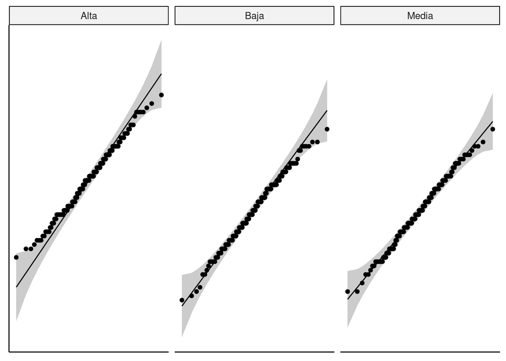

```r
g1 <- ggqqplot(fisica, x = "tiempo", y = "dificultad", alpha = 0.7, palette = c("steelblue","steelblue1","steelblue4"))
g1 <- g1 + facet_wrap(~ dificultad)
g1 <- g1 + rremove("x.ticks") + rremove("x.text")
g1 <- g1 + rremove("y.ticks") + rremove("y.text")
g1 <- g1 + rremove("axis.title")
g1
```

El gráfico anterior permite suponer razonablemente que las muestras provienen de una distribución similar a la normal. A pesar de que hay algunos puntos que pueden estar cercanos a salir de esta, dado esto, en pruebas posteriores se usará un nivel de significancia mas exigente, el cual será de 0.025.

4. La condición de esfericidad se comprueba posteriormente en la prueba ANOVA y en caso de no cumplirse esta misma hace su corrección.

Una vez comprobadas las condiciones, procedemos a aplicar la prueba ANOVA.

```r
prueba_ez <- ezANOVA(data = fisica, dv= tiempo, wid = .(id), within = dificultad)
prueba_ez
```

```
## $ANOVA
##       Effect DFn DFd        F            p p<.05       ges
## 2 dificultad   2 398 70.71079 5.284426e-27     * 0.1694951
##
## $`Mauchly's Test for Sphericity`
##       Effect         W        p p<.05
## 2 dificultad 0.9990732 0.912293
##
## $`Sphericity Corrections`
##       Effect       GGe       p[GG] p[GG]<.05      HFe        p[HF] p[HF]<.05
## 2 dificultad 0.9990741 5.56544e-27         * 1.009203 5.284426e-27         *
```

Como se puede ver el valor de p es minúsculo, en comparación con nuestro nivel de significancia (0.025), por lo que se rechaza la hipótesis nula en favor de la hipótesis alternativa. Obteniendo así, que al menos uno de los niveles de dificultad difiere en tiempo promedio de los otros niveles de dificultad.

Además nos permite ver si se cumple el supuesto de esfericidad, donde p = 0.9122, el cual es mayor a 0.025, lo que nos permite concluir que se cumple con el supuesto de esfericidad.

#### Tamaño del efecto

También se puede obtener una aproximación gráfica del tamaño del efecto:

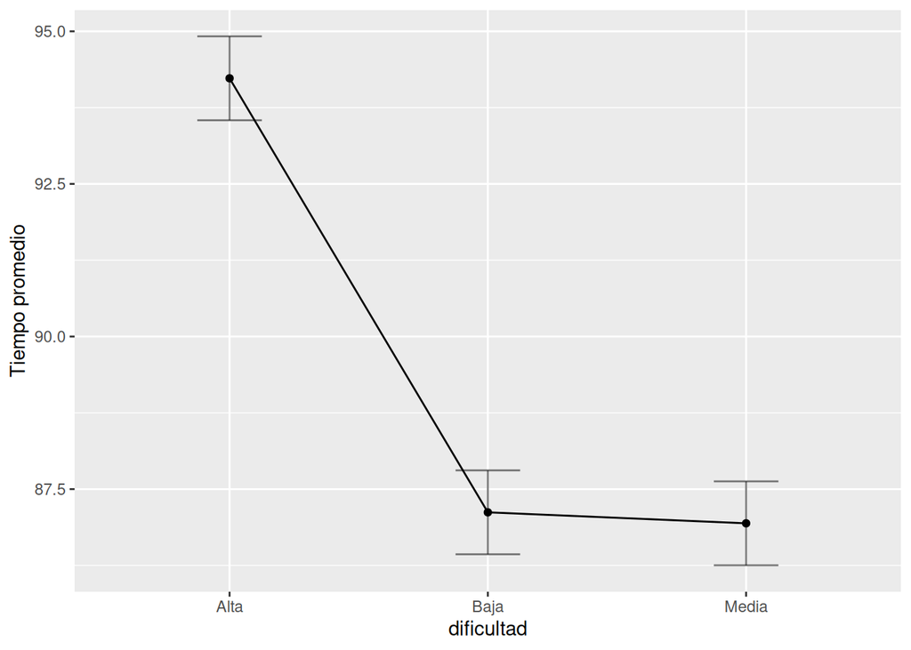

```r
g2 <- ezPlot(data = fisica, dv = tiempo, wid = .(id), within = dificultad,
             y_lab = "Tiempo promedio", x = dificultad)
g2
```

Aquí se puede observar que el nivel de dificultad alta se escapa del tiempo promedio de la dificultad baja y media. Pero para poder obtener una respuesta mas exacta y confiable, se realiza un procedimiento post-hoc.

#### Procedimiento POST-HOC

```r
alfa <- 0.025

holm <- pairwise.t.test(fisica[["tiempo"]], fisica[["dificultad"]],
                        p.adj = "holm", paired = TRUE, conf.level = 1-alfa)
holm
```

```
##
##  Pairwise comparisons using paired t tests
##
## data:  fisica[["tiempo"]] and fisica[["dificultad"]]
##
##       Alta   Baja
## Baja  <2e-16 -
## Media <2e-16 0.8
##
## P value adjustment method: holm
```

Una vez realizado el procedimiento post-hoc, se puede ver que el valor p que relaciona la dificultad alta con la dificultad baja y media es demasiado bajo en comparación con el nivel de significancia planteado, mientras que el valor que relaciona la dificultad baja con la media es de 0.8, el cual es mayor al nivel de significancia planteado.

Por lo que para el nivel de dificultad alto se rechaza la hipótesis nula en favor de la alternativa, es decir que el promedio de tiempo que difiere de los otros es el de la dificultad alta, esto se puede afirmar con un 97.5% de confianza. Mientras que para el promedio de la dificultad baja y media no hay evidencia suficientes para rechazar la hipótesis nula, por lo que se puede decir con un 97.5% de confianza que estos promedios de tiempo no difieren significativamente.